# Tugas Individu 2

| Field | Data |
| --- | --- |
| Nama | Farhan Apri Kesuma |
| NIM | 121140179 |

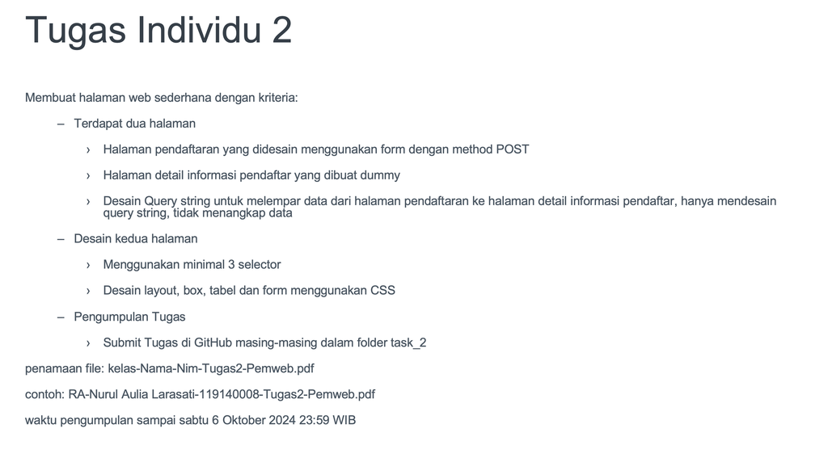

Pada tugas individu kali ini saya akan membuat halaman web sederhana dengan halaman utama adalah form pendaftaran yang memungkinkan user memasukkan data nama, email, nomor telepon, dan alamat dengan method `POST` lalu datanya akan tampil pada halaman detail pendaftar dengan `query string`

## Langkah kedua: Membuat Kerangka Web Pada Index dan Detail

Membuat kerangka pada setiap konponen yang dibutuhkan pada halaman index dan detail. Berikut ini adalah kerangka pada index:

```
<!DOCTYPE html>
<html lang="en">
  <head>
    <meta charset="UTF-8" />
    <meta name="viewport" content="width=device-width, initial-scale=1.0" />
    <title>Halaman Pendaftaran</title>
    <link rel="stylesheet" href="assets/index.css" />
  </head>
  <body>
    <header>
      <h1>Form Pendaftaran</h1>
    </header>

    <div class="container">
      <form id="formRegistrasi" action="detail.html" method="POST">
        <label for="nama">Nama:</label>
        <input type="nama" id="nama" name="nama" required />
        <label for="email">Email:</label>
        <input type="email" id="email" name="email" required />
        <label for="telepon">Telepon:</label>
        <input type="telepon" id="telepon" name="telepon" required />
        <label for="alamat">Alamat:</label>
        <input type="alamat" id="alamat" name="alamat" required />
        <input type="submit" value="Daftar" />
      </form>
    </div>
  </body>
</html>
```

Dan ini kerangka pada detail:

```
<!DOCTYPE html>
<html lang="en">
<head>
    <meta charset="UTF-8">
    <meta name="viewport" content="width=device-width, initial-scale=1.0">
    <title>Detail Informasi Pendaftar</title>
    <link rel="stylesheet" href="assets/detail.css">
</head>
<body>
    <div class="container">
        <h1>Detail Informasi Pendaftar</h1>
        <table>
            <tr>
                <th>Nama</th>
                <td id="nama"></td>
            </tr>
            <tr>
                <th>Email</th>
                <td id="email"></td>
            </tr>
            <tr>
                <th>Telepon</th>
                <td id="telepon"></td>
            </tr>
            <tr>
                <th>Alamat</th>
                <td id="alamat"></td>
            </tr>
        </table>
    </div>

</body>
</html>
```

## Langkah ketiga: Mulai Melakukan Styling CSS Untuk Index dan Detail

Setelah kerangka sudah selesai dibuat beserta selector-nya, lanjut membuat berkas `.css` pada folder `assets`. Berikut susunan file-nya.

[figure not shown]

Setelah itu, saya lakukan styling pada index dengan css berikut:

```
body {
  font-family: Arial, sans-serif;
  margin: 0;
  padding: 0;
  background-color: #f4f4f4;
}

.container {
  width: 50%;
  margin: auto;
  overflow: hidden;
  padding: 20px;
}

header {
  background: #333;
  color: #fff;
  padding-top: 30px;
  min-height: 70px;
  border-bottom: #77aaff 3px solid;
}

header h1 {
  text-align: center;
  text-transform: uppercase;
  margin: 0;
}

form {
  background: #fff;
  padding: 20px;
  margin-top: 20px;
  border: 1px solid #ccc;
  box-shadow: 0 0 10px rgba(0, 0, 0, 0.1);
}

form input[type="nama"],
form input[type="email"],
form input[type="telepon"],
form input[type="alamat"],
form input[type="submit"] {
  width: calc(100%);
  padding: 10px;
  margin: 10px 0;
  box-sizing: border-box;
}

form input[type="submit"] {
  background: #333;
  color: #fff;
  border: 0;
  cursor: pointer;
}

form input[type="submit"]:hover {
  background: #1b1b1b;
}
```

Dan pada detail sebagai berikut:

```
body {
    font-family: Arial, sans-serif;
    background-color: #f4f4f4;
    margin: 0;
    padding: 0;
}

.container {
    width: 80%;
    margin: 0 auto;
    background-color: #fff;
    padding: 20px;
    box-shadow: 0 0 10px rgba(0, 0, 0, 0.1);
    margin-top: 20px;
}

h1 {
    text-align: center;
    color: #333;
}

table {
    width: 100%;
    border-collapse: collapse;
    margin-top: 20px;
}

table, th, td {
    border: 1px solid #ddd;
}

th, td {
    padding: 10px;
    text-align: left;
}

th {
    background-color: #f2f2f2;
}
```

## Langkah keempat: Mendesain Query String

Setelah web sudah menjadi cantik dengan css, saya merancang query string saya untuk form input, pada `Langkah kedua` bisa dilihat desain query string untuk setiap input field pada form pendaftaran.

```
<form id="formRegistrasi" action="detail.html" method="POST">
  <label for="nama">Nama:</label>
  <input type="nama" id="nama" name="nama" required />
  <label for="email">Email:</label>
  <input type="email" id="email" name="email" required />
  <label for="telepon">Telepon:</label>
  <input type="telepon" id="telepon" name="telepon" required />
  <label for="alamat">Alamat:</label>
  <input type="alamat" id="alamat" name="alamat" required />
  <input type="submit" value="Daftar" />
</form>
```

Dan ini hasil desain query string akan muncul pada *search link bar* pada *browser*

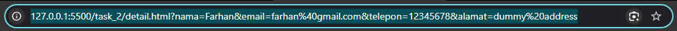

Tampak ada data `nama`, `email`, `telepon`, dan `alamat`

## Tambahan: Melempar Data ke Halaman Detail

Karena saya memiliki rasa penasaran yang tinggi, saya mencoba untuk melempar data dari halaman form dengan query string dan method POST ke halaman detail menggunakan sedikit `JavaScript`. Berikut script pada form:

```
document.getElementById("formRegistrasi").addEventListener("submit", function (event) {
    event.preventDefault();

    const nama = document.getElementById("nama").value;
    const email = document.getElementById("email").value;
    const telepon = document.getElementById("telepon").value;
    const alamat = document.getElementById("alamat").value;

    const queryString = `nama=${encodeURIComponent(nama)}&email=${encodeURIComponent(email)}&telepon=${encodeURIComponent(telepon)}&alamat=${encodeURIComponent(alamat)}`;
    window.location.href = `detail.html?${queryString}`;
});
```

sedikit penjelasan kode:

- `event.preventDefault()`: Untuk mencegah pengiriman form secara default.
- `const -data- = document.getElementById('-data-').value`: Untuk mengambil nilai dari form.
- `const queryString`: Variabel yang berisi query string yang nantinya akan dilakukan Redirect.
- `window.location.href`: Variabel yang berisi Redirect untuk mengarah ke halaman detail sekaligus membawa data dari form.

Dan berikut adalah script pada detail untuk menangkap data:

```
const url = new URLSearchParams(window.location.search);

document.getElementById('nama').textContent = url.get('nama');
document.getElementById('email').textContent = url.get('email');
document.getElementById('telepon').textContent = url.get('telepon');
document.getElementById('alamat').textContent = url.get('alamat');
```

sedikit penjelasan kode:

- `const url`: Untuk wadah url dari query string yang dikirim.
- `document.getElementById('-data-').textContent = url.get('-data-')`: Untuk meletakkan masing-masing nilai dari query string berdasarkan url yang dikirim (*redirect*) yakni nama, email, telepon, dan alamat.

## Preview Tampilan

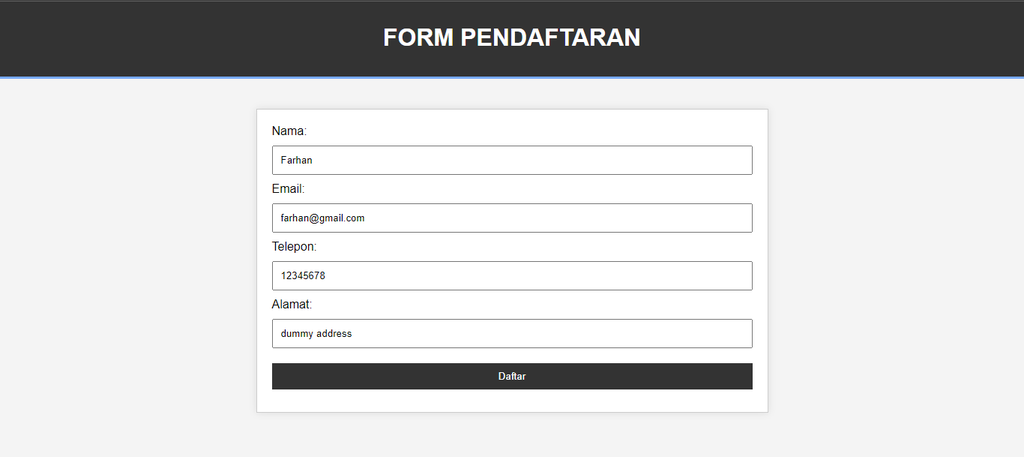

Halaman Form

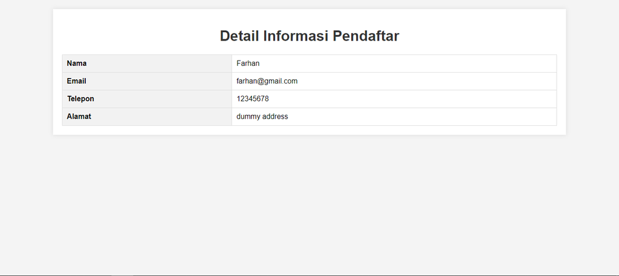

Halaman Detail

## Link Github Tugas

Tugas ini saya push ke repository **if3028-pemweb** saya ke dalam folder **task_2** pada branch `tugas`. Untuk mengakesnya silahkan klik tulisan yang bercetak tebal atau boleh klik link berikut jika anda bingung:

**https://github.com/parhannn/if3028-pemweb/tree/tugas/task_2**